# Teste Prático Época 2

Diogo Alexandre Alonso de Freitas

2023-01-18

## Enunciado

### Ponto prévio

1. Definir a variável **nfish**, igual ao valor que se obtém somando 20 ao resto da divisão inteira do vosso número de aluno por 10.

```r
nfish = (20 + (104841 %% 10))
```

2. Definir as variáveis **pa** e **pb** da seguinte forma:

   Seja a – o primeiro dígito diferente de 0, a contar a partir da direita no vosso número de aluno

   e b – o segundo dígito diferente de 0, a contar a partir da direita no vosso número de aluno.

   Então, pa = max (a,b)+2 e pb = min (a,b)+1

```r
a <- 1
b <- 4

pa = max(a,b) + 2
pb = min (a,b) + 1
```

3. definir **n1**, **n2** e **n3** da seguinte forma:

   n1 obtém-se somando 2 ao resto da divisão inteira do vosso número de aluno por 3

   n2 obtém-se pelo quociente da divisão inteira do vosso número de aluno por 10000

   n3 obtém-se somando 3 ao resto da divisão inteira do vosso número de aluno por 3

```r
n1 <- 2 + (104841 %% 3)
n2 <- 104841 %/% 10000
n3 <- 3 + (104841 %% 3)
```

4. Finalmente, a variável **nreplica** será igual ao vosso número de aluno.

```r
nreplica <- 104841
```

### GRUPO 1 (6 valores).

O cutefish existente numa certa barragem é identificado por 30% de cutefish dourado e 70% de cutefish prateado. Da experiência passada, sabe-se que 50% de cutefish dourado nessa barragem tem peso inferior ao estabelecido nos regulamentos de pesca desportiva, enquanto que, no cutefish prateado, esse valor é de 40%.

Assim, cada cutefish pode ser classificado segundo duas vertentes: a sua subespécie (D – dourado ou P – prateado) e o escalão em termos de peso (I – inferior ao regulamento ou R – não inferior ao regulamento).

### 1.1.

Considere a experiência aleatória que consiste em capturar um cutefish e registar a sua subespécie e escalão.

#### 1.1.1.

Construa um dataframe que contenha todos os possíveis resultados da experiência aleatória descrita.

#### 1.1.2.

Adicione ao dataframe que construiu na alínea anterior uma coluna, “prob”, com a probabilidade de ocorrência de cada um dos resultados. As probabilidades referidas têm de ser calculadas a partir dos valores acima fornecidos; a mera indicação das probabilidades, sem a sua derivação a partir dos dados fornecidos, será severamente penalizada.

#### 1.1.3.

Mostre o dataframe construído

```r
# Resolução de 1.1

# 1.1.1
peixe <- c("D","P")
escalao_peso <- c("I","R")
tabela_pei <- expand.grid(peixe,escalao_peso)
tabela_pei
```

```
##   Var1 Var2
## 1    D    I
## 2    P    I
## 3    D    R
## 4    P    R
```

```r
# 1.1.2
# verificar
con_d <- 50/100
con_p <- 40/100

prob_peso_s_pei<-c(.3,.7)

prob_d<-c(1-con_d,con_d)
prob_p<-c(1-con_p,con_p)

prob1<-rbind(prob_d,prob_p)
prob2<-prob_peso_s_pei*prob1

tabela_pei$prob <- c(prob2[,1],prob2[,2])

# 1.1.3
tabela_pei
```

```
##   Var1 Var2 prob
## 1    D    I 0.15
## 2    P    I 0.42
## 3    D    R 0.15
## 4    P    R 0.28
```

### 1.2.

Admita que um certo pescador desportivo, durante uma competição, conseguiu capturar **nfish** cutefish.

#### 1.2.1.

Obtenha uma simulação da pescaria desse pescador, que respeite as condições de ocorrência indicadas.

NOTA: caso **não** tenha conseguido fazer a alínea 1.1.2, construe um vetor “prob” **com a estrutura adequada**, e use-o quando necessário na resolução desta questão 1.2. Caso o faça, identifique claramente a sua opção

#### 1.2.2.

Qual a percentagem de cutefish dourados no resultado da competição desse pescador?

#### 1.2.3.

Na competição em causa, a cada peixe com peso **não inferior** ao regulamentado é atribuída uma pontuação de **pa pontos positivos** e a cada peixe com peso **inferior** ao regulamentado é atribuída uma pontuação de **pb pontos negativos**.

Na simulação obtida, calcule a pontuação do pescador. Quantos pontos conseguiu ele arrecadar, em média, por cada cutefish capturado?

```r
# Resolução de 1.2

# 1.2.1
simul1<-sample(1:nrow(tabela_pei),nfish,replace=TRUE,prob=tabela_pei$prob)
simul2<-tabela_pei[simul1,1:2]

# 1.2.2
total_d <- length(which(simul2$Var1=="D"))
per_d <- total_d/nrow(simul2)*100

# 1.2.3
pontos <- ifelse(simul2$Var2=="R",pa,pb)
sum_pontos <- sum(pontos)
sum_pontos
```

```
## [1] 70
```

```r
media_pon <- sum_pontos/length(pontos)
```

> O pescador conseguiu arrecadar em média $3.33$ pontos por peixe capturado.

## GRUPO 2 (6 valores)

Um utilizador submete pedidos a um servidor de base de Dados, que só podem ser de 3 tipos: query, add/modify e delete.

O tempo de execução desses pedidos pode ser modelizado por distribuições Normais, com médias de 100 milissegundos para uma query, 200 milissegundos para um add/modify e 220 milissegundos para um delete sendo os desvios-padrão de 10 milissegundos para uma query e 30 milissegundos quer no caso de um add/modify, quer no caso de um delete.

Um utilizador irá submeter, em sequência, **n1** pedidos de query, **n2** add/modify e **n3** pedidos delete. Admite-se a independência dos pedidos.

### 2.1.

Calcule os parâmetros caracterizadores da variável XT – Tempo total (em milissegundos) da sequência. Represente graficamente a função densidade de XT.

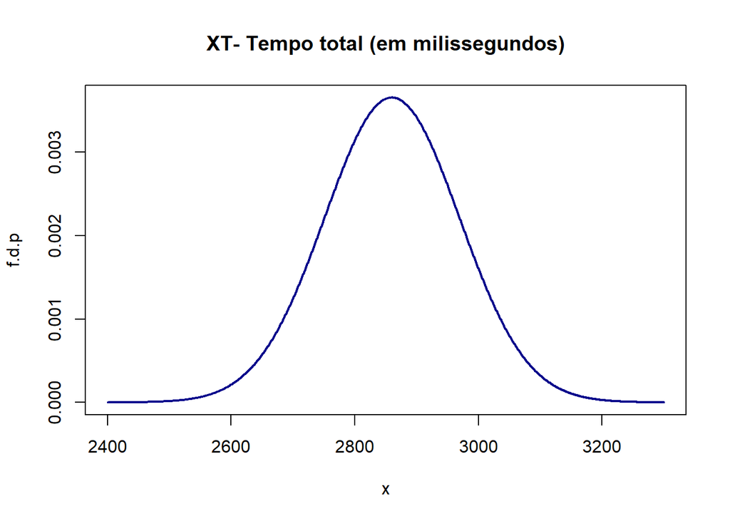

```r
# Resolução de 2.1
query <- c(100, 10)
add_modify <- c(200, 30)
delete <- c(220, 30)

queryN1 <- c(100*n1, 10*sqrt(n1))
add_modifyN2 <- c(200*n2, 30*sqrt(n2))
deleteN3 <- c(220*n3, 30*sqrt(n3))

XT <- c(queryN1[1]+add_modifyN2[1]+deleteN3[1], sqrt(queryN1[2]^2 + add_modifyN2[2]^2 + deleteN3[2]^2))

x <- (2400:3300)

plot(x, dnorm(x, mean=XT[1], sd=XT[2]), type = "l", main = "XT- Tempo total (em milissegundos)",
     ylab = "f.d.p",lwd = 2, col = "darkblue")
```

### 2.2.

Calcule a probabilidade do tempo total de execução dos pedidos ser pelo menos 3000 milissegundos. Represente a área em causa no gráfico.

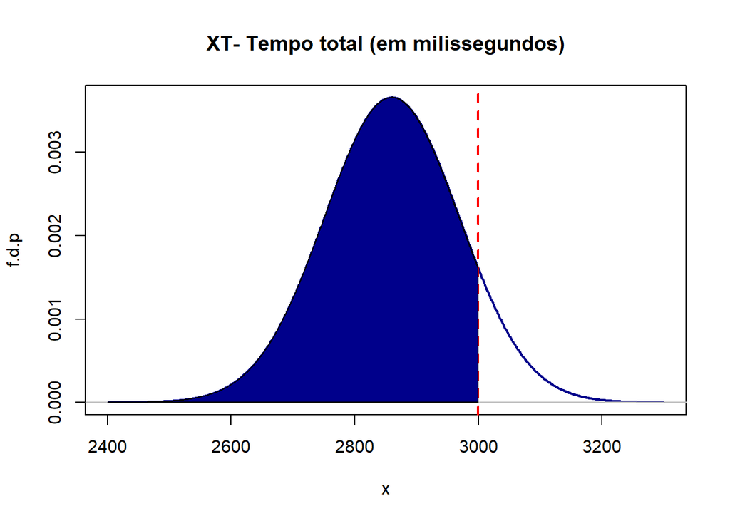

```r
# Verificar
# Resolução de 2.2

eixo_x<-c(2400:3300)
eixo_y<-c(0,dnorm(0))

plot(x, dnorm(x, mean=XT[1], sd=XT[2]), type = "l", main = "XT- Tempo total (em milissegundos)",
     ylab = "f.d.p",lwd = 2, col = "darkblue")

# Add x and y-axis lines
abline(h = 0, col="grey")
abline(v = 0, col = "black", lty=2, lwd=2)
abline(v = qnorm(0.9, mean = XT[1], sd = XT[2]), col = "red", lty=2, lwd=2)

#marcar a área

x1 <- seq(2400,qnorm(0.9, mean = XT[1], sd = XT[2]),0.01)
y1 <- dnorm(x1, mean=XT[1], sd=XT[2])

coord_x <- c(2400,x1,qnorm(0.9, mean = XT[1], sd = XT[2]))
coord_y <- c(0,y1,0)
polygon(coord_x,coord_y,col='blue4')
```